# second week: Introduction to R and Rstudio

Mobile Data

benyamin jami al ahmadi 94105282

2018-02-19 23:58:53

# تمرین سری دوم: تلفن همراه شناسی!

> با استفاده از داده های گوشی های همراه به سوالات زیر پاسخ دهید. برای رسم نمودار از پکیج ggplot2 استفاده کنید.

۱. کدام شرکت بیشترین تعداد گوشی را تولید کرده است؟ نمودار ستونی ۲۰ شرکت برتر بر حسب تعداد گوشی تولید کرده را رسم کنید.

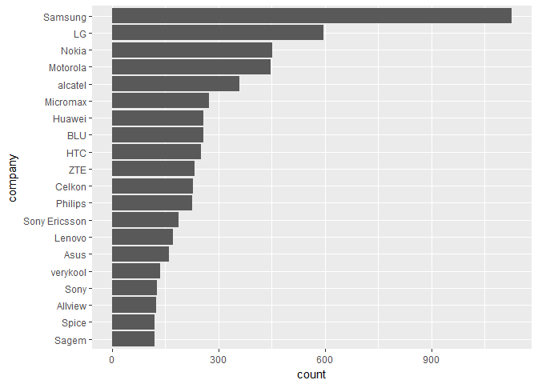

```r
mobile %>% group_by(company) %>% summarise(count = n()) %>% arrange(-count) %>% head(20) %>% ggplot(aes(x = reorder(company,count), y = count)) + xlab('company') + geom_bar(,stat = 'identity') + coord_flip()
```

۲. نمودار زمانی طول عرض ضخامت و کیفیت دوربین گوشی ها را بکشید و به نمودار هر یک مدل خطی اضافه کنید.

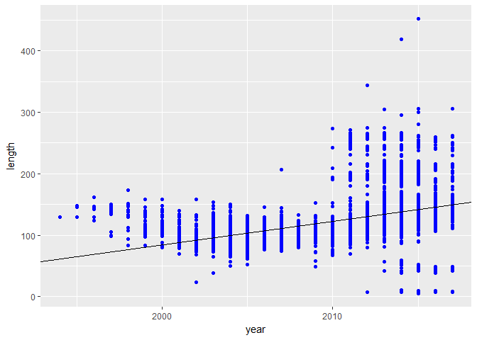

```r
coef = coef(lm(dim_length ~ year, data = mobile))
ggplot(mobile,aes(x = year,y = (dim_length))) + geom_point(color = "blue") + geom_abline(intercept = coef[1], slope = coef[2]) + ylab('length')
```

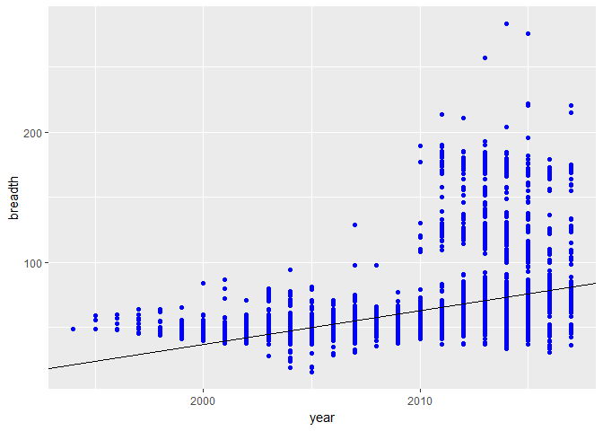

```r
coef = coef(lm(dim_breadth ~ year, data = mobile))
ggplot(mobile,aes(x = year,y = (dim_breadth))) + geom_point(color="blue") + geom_abline(intercept = coef[1], slope = coef[2]) + ylab('breadth')
```

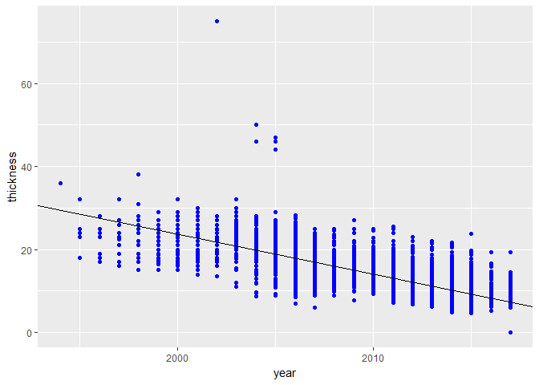

```r
coef = coef(lm(dim_thickness ~ year, data = mobile))
ggplot(mobile,aes(x = year,y = (dim_thickness))) + geom_point(color="blue") + geom_abline(intercept = coef[1], slope = coef[2]) + ylab('thickness')
```

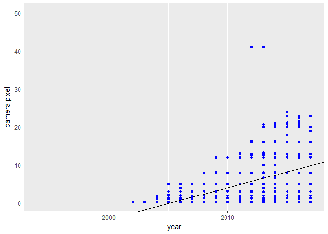

```r
coef = coef(lm(cam_px ~ year, data = mobile))
ggplot(mobile,aes(x = year,y = cam_px)) + geom_point(color="blue") + geom_abline(intercept = coef[1], slope = coef[2])+ylab('camera pixel')
```

۳. نمودار ستونی متوسط قیمت گوشی بر حسب تعداد سیم کارت و دسترسی به LTE را رسم نمایید.

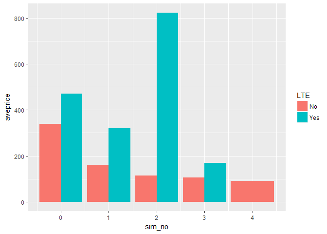

```r
mobile %>% group_by(LTE,sim_no) %>% summarise(aveprice = mean(price,na.rm=T)) %>%
  ggplot(aes(x = sim_no,y = aveprice)) + geom_bar(stat = 'identity',aes(fill = LTE),position = 'dodge')
```

۴. نمودار جعبه ایی ضحامت گوشی هایی که در سال ۲۰۱۷ معرفی شده اند را برحسب اینکه کمیت جک هدفون رسم نمایید

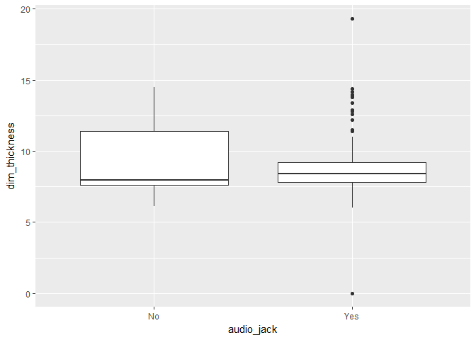

```r
mobile %>% filter(!is.na(audio_jack),year == 2017)%>% ggplot(aes(audio_jack,dim_thickness)) + geom_boxplot()
```

۵. مفهوم ppi را در گوشی های موبایل محاسبه و هیستوگرام آن را رسم نمایید. همچنین نمودار سالانه متوسط این کمیت را بکشید. کدام گوشی بیشترین ppi را دارد؟

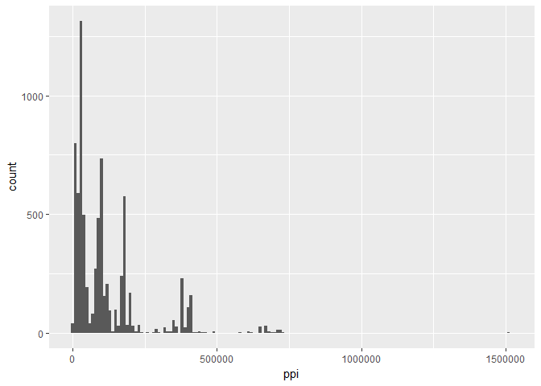

```r
mobile %>% mutate(ppi = (px_row*px_col)/display_size) ->case5
case5 %>% ggplot(aes(ppi)) + geom_histogram(binwidth = 10000)
```

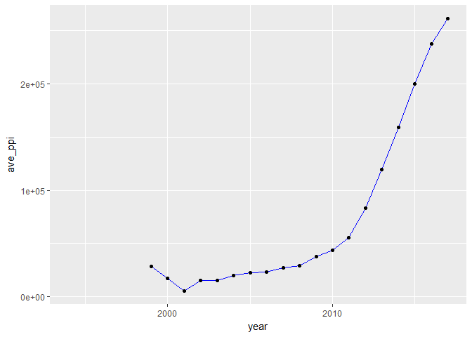

```r
case5 %>% group_by(year,na.rm=T) %>% summarise(ave_ppi = mean(ppi,na.rm=T)) %>% ggplot(aes(year,ave_ppi)) + geom_line(color = "blue") + geom_point()
```

```r
case5[which.max(case5$ppi),1:2]
```

```
##      company            device
## 7426    Sony Xperia XZ Premium
```

۶. در گذشته به بعضی از مدل های گوشی نوکیا **گوشکوب** گفته می شد. سعی کنید برای این مفهوم کمیتی مناسب تعریف کنید . ده گوشکوب برتر را پیدا کرده و نمودار گوشکوبیت آن را رسم نمایید.

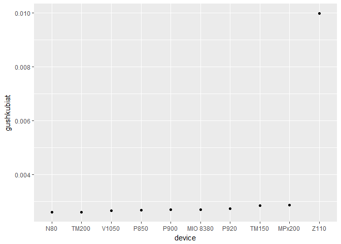

```r
mobile %>% filter(display_size > 2)%>% mutate(gushkubiat = dim_thickness/(dim_breadth * dim_length * display_size)) %>% filter(is.finite(gushkubiat)) %>% arrange(-gushkubiat) %>% head(10) %>% ggplot(aes(x = reorder(device , gushkubiat),y = gushkubiat)) + geom_point() + xlab('device')
```

۷. آیا تلفن همراهی وجود دارد که در آب غرق نشود؟ اگر جواب بله هست تمام گوشی های که این خاصیت را دارند بیابید. با کشیدن یک نمودار به این سوال پاسخ دهید.

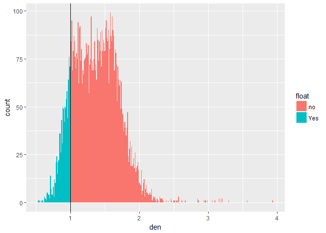

```r
mobile %>% mutate(den = 1000*weight/(dim_length*dim_thickness*dim_breadth)) %>% mutate(float = ifelse(den < 1,'Yes','no')) %>%  filter(den < 4) -> case4
case4 %>% filter(float == "Yes") -> case42
case4 %>% ggplot(aes(x = den,fill = float)) + geom_histogram(binwidth = 0.01) + geom_vline(xintercept = 1)
```

۸. نمودار پراکنش حجم ذخیره سازی باطری و وزن را رسم نمایید. میزان همبستگی بین این دو کمیت را محاسبه کنید.

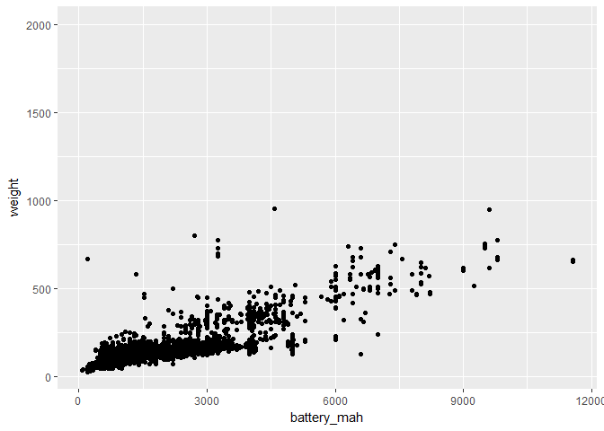

```r
mobile %>% ggplot(aes(x = battery_mah, y = weight)) + geom_point()
```

```r
mobile %>% filter(!is.na(battery_mah), !is.na(weight)) -> case8
print("correlation coefficient = ")
```

```
## [1] "correlation coefficient = "
```

```r
cor(case8$battery_mah, case8$weight, method = "pearson")
```

```
## [1] 0.8086273
```

۹. قیمت پرچمداران یک برند خاص مثلا سامسونگ را بیابید و نمودار قیمت زمان و نام مدل را رسم نمایید.

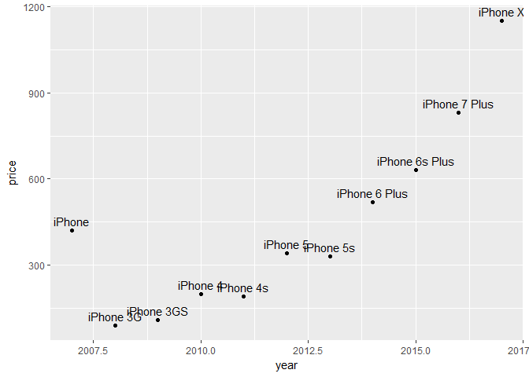

```r
mobile %>% filter(company == 'Apple',is.finite(price),display_size < 6,display_size > 2) %>% group_by(year) %>% summarise(price = max(price,na.rm=T),device = device[which(price == max(price,na.rm=T))]) %>%  ggplot(aes(x = year, y = price)) + geom_point() + geom_text(aes(label = device),hjust = +0.5,vjust = -0.5)
```

۱۰. سه نمودار جالب رسم کنید و توضیح دهید چرا از نظر شما جالب است؟

الف)نمودار شرکت های تولید کننده گوشی در هر سال. میتوان شرکت های تازه به وجود آمده و از بین رفته در هر سال را مشاهده کرد.

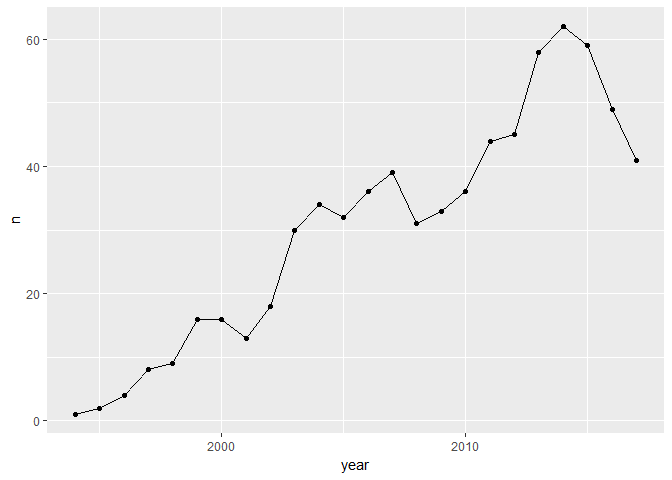

```r
mobile %>% group_by(year,company) %>%  summarise(n = n()) %>% group_by(year) %>% summarise( n = n()) %>% ggplot(aes(x = year,y=n)) + geom_point() + geom_line()
```

ب)نسبت صفحه نمایش به سطح گوشی 10 گوشی برتر در این زمینه. در حای حاضز نسبت مساحت صفحه نمایش به سطح گوشی معیار بسیار مهمی در زیبایی گوشی ها تبدیل شده.

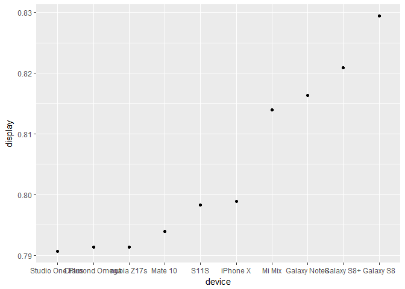

```r
mobile %>% filter(display_size < 7, display_size > 2,year > 2015) %>% mutate(display = (2.5^2*display_size^2*aspect_row*aspect_col * 100/(aspect_row^2+aspect_col^2) )/(dim_length * dim_breadth)) %>% arrange(-display) %>% head(10) %>%  ggplot(aes(x = reorder(device,display),y = display)) + geom_point() + xlab('device')
```

ج)نسبت های ابعاد صفحه نمایش پر طرفدار در سال 2017 این نسبت تاثیر زیادی بر زیبایی و خوش دستی گوشی دارد

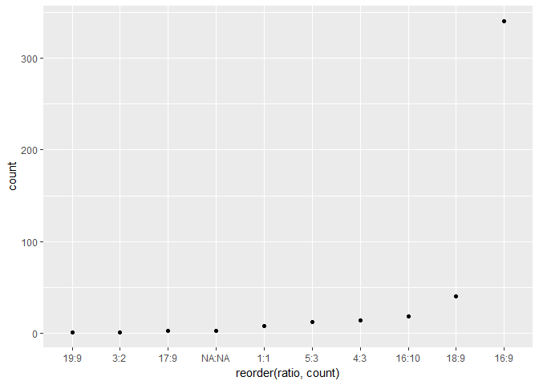

```r
mobile %>% filter(year == 2017)%>% mutate(ratio = paste(aspect_row,aspect_col,sep = ':')) %>% group_by(ratio) %>% summarise(count = n()) %>% ggplot(aes(reorder(ratio,count),count)) + geom_point()
```